# Dealing and Taking Damage

In tower defense games, enemy units damage the player’s base if they get close to it. The player will lose the game if their base takes too much damage.

The player must create towers which deal damage to enemies to destroy them before they reach the player’s base.

In this lesson, we’ll code hit boxes and hurt boxes. Hit boxes deal damage, while hurt boxes receive damage. They’re useful in lots of different games which have damage systems such as fighting or adventure games.

We use areas or physics bodies to detect collisions between a damage-dealers and receivers.

In this lesson, you’ll learn to:

- Manage physics layers.
- Detect when areas overlap.
- Filter different damage sources.
- Deal damage to units.

## Designing the hit system

We’ll abstract combat into two entities which handle hits from different perspectives. The hitbox entity deals damage, while the hurtbox receives damage.

Hitboxes are for anything that should deal damage, such as bullets or enemies. A hurtbox is for anything that should take damage, such as the player’s base. Some scenes, like enemies, will have both.

Two scenes represent these entities: - *HitBoxArea2D* is our damage dealer. - *HurtBoxArea2D* will receive damage dealt by *HitBoxArea2D*.

As suggested by their names, they both extend

[figure not shown]

`Area2D`.

*Using this separation can be unnecessary in simple combat systems. However, games with more complex combat interactions benefit from having dedicated components. That’s why we decided to use this approach in this series.*

*Enemies*, *Bullets*, and the *PlayerBase* uses these to make them interact with each other.

Here’s a diagram of our desired code structure.

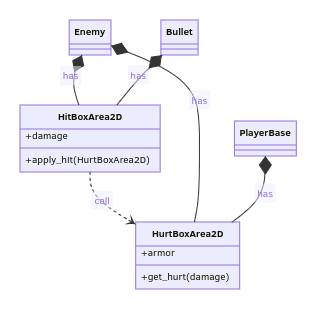

The *HitBoxArea2D* and the *HurtBoxArea2D* should only interact with each other. We need to make sure they don’t detect unrelated areas so we have them monitor a dedicated physics layer named *combat*.

It’s a good practice to label our physics layers. These are already named in the start project. You can see them in the *Project Settings > General > Layer Names > 2d Physics*.

We’re using *Layer 2* because *Layer 1* is the default layer. If we use only *Layer 1*, we risk having physics objects interacting with the combat system accidentally.

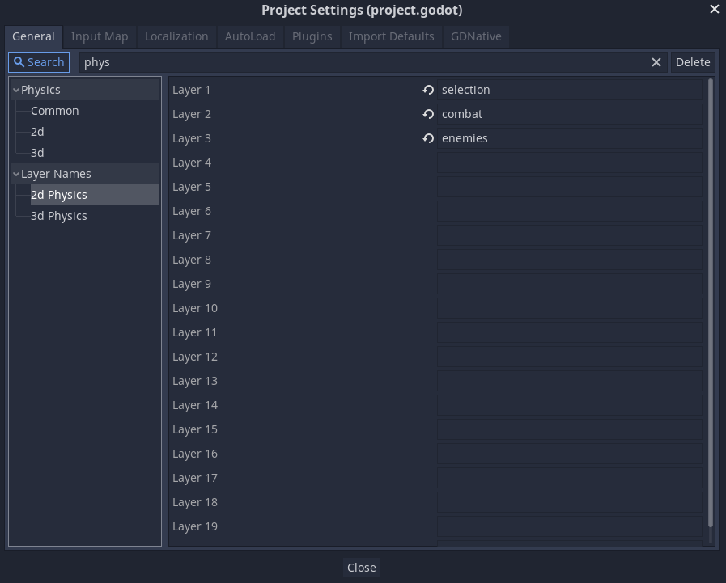

## Dealing damage with a hitbox

Let’s start with the damage dealer, the *HitBoxArea2D*. Create a new scene with an *Area2D* as the root node named *HitBoxArea2D*. Save it as `res://Objects/HitBox/HitBoxArea2D.tscn`.

The *HitBoxArea2D*’s responsibility is to send the hit’s data to the *HurtBoxArea2D* when they overlap.

Since the *HitBoxArea2D* detects the overlap with the *HurtBoxArea2Ds*, it shouldn’t be inside any *Collision Layer*. Instead, it only masks the *Combat* layer.

In the *Inspector*, disable all *Collision Layer* bits. In the *Collision Mask* property, make sure to disable the bit `0` and enable bit `1`, which corresponds to the combat physics layer.

To ensure that nothing else interacts with the *HitBoxArea2D*, we toggle off the *Monitorable* property.

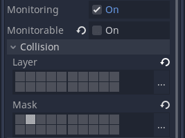

HitBoxArea2D’s node settings

Let’s code its behavior. Add a new script to the *HitBoxArea2D* and open it.

Hitboxes only take hits from specific sources. For example, the player’s towers shouldn’t damage their base. Also, enemies shouldn’t hurt each other.

For that, we need to know the hit’s source. In our game, there are only two possible damage sources; either the hit comes from the player or the enemies.

We use an enum to differentiate the two.

```
class_name HitBoxArea2D
extends Area2D

enum Teams { PLAYER, ENEMY }
# We export the value so we can set it from the Inspector.
# Using the enum as a type hint gives us a drop-down menu.
export (Teams) var team := Teams.PLAYER
```

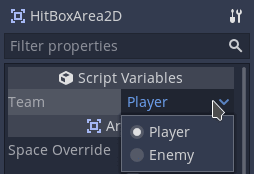

Our hitbox should then hold the hit’s source data, like damage and whether it can hit multiple targets.

A missile could explode and generate a large hitbox, touching multiple enemies.

We add two exported properties to handle that.

```
export var damage := 1
## If `true`, this hitbox can deal damage to multiple targets.
export var can_hit_multiple := false
```

Now, we need to detect when a *HitBoxArea2D* overlaps with a *HurtBoxArea2D*. Since they are areas, we can use their `area_entered` signal.

Connect the *HitBoxArea2D*’s `area_entered` signal to a new `_on_area_entered()` callback.

When the overlap happens, the *HitBoxArea2D* applies the hit on the *HurtBoxArea2D* if it’s in a different `team`.

```
func apply_hit(hurt_box: HurtBoxArea2D) -> void:
    if team == hurt_box.team:
        return
    # We have yet to create the hurt box but we'll define a `get_hurt()` method
    # on it to receive damage.
    hurt_box.get_hurt(damage)

    # If this hitbox can only hit one target, we turn off its `monitoring`
    # property.
    # We use `set_deferred()` to do so because we can't toggle the property
    # while the engine is processing physics.
    set_deferred("monitoring", can_hit_multiple)


# When an area overlaps with our hitbox, we apply a hit to it.
func _on_area_entered(area: Area2D) -> void:
    apply_hit(area)
```

With that, we can deal damage. However, we can’t take it yet! There’s be an error saying `HurtBoxArea2D` doesn’t exist.

## Processing damage with a hurt box

Now let’s make the *HurtBoxArea2D*. Create a new scene with an *Area2D* named *HurtBoxArea2D*. Save it as `res://Objects/HurtBox/HurtBoxArea2D.tscn`.

The *HurtBoxArea2Ds* complements the *HitBoxArea2D*. It doesn’t have any *Collision Mask*, but it’s inside the *Combat* *Collision Layer*.

To prevent interactions between multiple hurt boxes, let’s toggle off its *Monitoring* property.

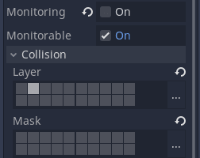

Add a new script to the *HurtBoxArea2D*.

The node should process the hit dealt by a *HitBoxArea2D*. It takes the raw hit data and calculates the final damage, which we emit along with a `hit_landed` signal, allowing other nodes to subtract health or display damage numbers.

```
## Receives hits dealt by a HitBoxArea2D
class_name HurtBoxArea2D
extends Area2D

## Emitted when receiving a hit.
signal hit_landed(damage)

# Like the HitBoxArea2D, we use the `team` to distinguish the player base from
# enemies.
enum Teams { PLAYER, ENEMY }
export (Teams) var team := Teams.PLAYER

# An entity may have some armor rating, reducing incoming damage.
export var armor := 0


## Called by `HitBoxArea2D` when it interacts with this hurt box.
func get_hurt(damage: int) -> void:
    var final_damage := damage - armor
    # We emit the final damage as a signal to let other nodes apply it, display
    # it, and so on.
    emit_signal("hit_landed", final_damage)
```

The result may look simple at this point, but it’s scalable. We can extend the code to apply status effects, give enemies resistance to specific effects, and more.

## Testing hits

We should test our classes to make sure they work.

To do so, create a new scene with a *HitBoxArea2D* and *HurtBoxArea2D* instance. Add a *CollisionShape2D* as a child of each.

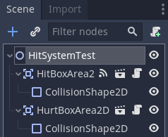

Then, make sure they overlap and have different *Team* settings, as shown below.

If you’re having trouble finding the exported variables, close and reopen the project. Godot may think there’s still and error with the `HitBoxArea2D.gd` script. We should have solved this after creating the `HurtBoxArea2D` class.

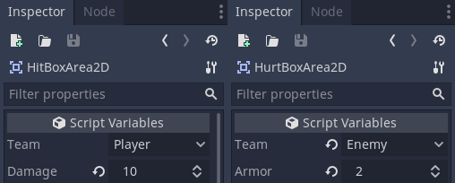

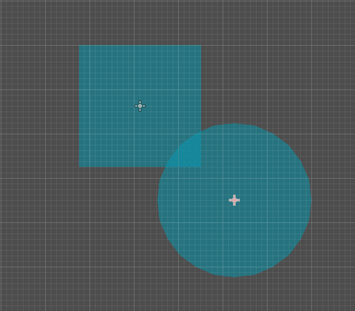

Add a breakpoint in the line where we emit the `hit_landed` signal in the `HurtBoxArea2D.gd`. The debugger should stop on the breakpoint as soon as you test the scene confirming that they interacted correctly.

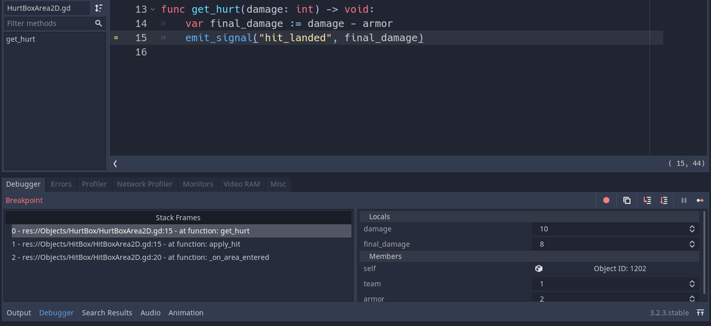

## The code so far

As reference, here is the complete code for the `HitBoxArea2D.gd` and the `HurtBoxArea2D.gd` so far.

`HitBoxArea2D.gd`

```
# Represents a Hit dealt from the attacker perspective
class_name HitBoxArea2D
extends Area2D

enum Teams { PLAYER, ENEMY }
export (Teams) var team := Teams.PLAYER

export var damage := 1
export var can_hit_multiple := false


func apply_hit(hurt_box: HurtBoxArea2D) -> void:
    if team == hurt_box.team:
        return
    hurt_box.get_hurt(damage)
    set_deferred("monitoring", can_hit_multiple)


func _on_area_entered(area: Area2D) -> void:
    apply_hit(area)
```

`HurtBoxArea2D.gd`

```
# Represents a Hit dealt from the target perspective
class_name HurtBoxArea2D
extends Area2D

signal hit_landed(damage)

enum Teams { PLAYER, ENEMY }
export (Teams) var team := Teams.PLAYER

export var armor := 0


func get_hurt(damage: int) -> void:
    var final_damage := damage - armor
    emit_signal("hit_landed", final_damage)
```